# ch05. 댠순 베이즈 분류

Jeong-Eun Lee

2021 10 6

- 단순 베이즈 분류 : 베이즈 정리에 기반한 방법 & 계산 단순화가 목적
  - 사후확률이 큰 집단으로 새로운 데이터를 분류함
  - 사후확률의 계산을 좀 더 편하게 할 수 있도록 예측변수들 간의 독립을 가정함
  - $p(C_j|x) = \frac {p(C_j)p(x|C_j)} {p(x)}$
    - posterior prob = prior prob * likelihood
  - $p(x|C_j) = p(x_1|C_j)p(x_2|C_j)...p(x_d|C_j)$
- 단순 베이즈 분류에서 낮은-빈도 문제를 해결하기 위해서는 모든 속성값-군집 조합에 대한 빈도에 작은 수를 더하여 계산을 수행하면 됨
- 사전확률을 정할 때에는 모집단의 빈도에 기초하는 것이 더 유연함
- 각 확률을 계산할 때에는 각 상황을 정규분포라고 가정하고 분포에 값을 대입하여 구함(-> 평균, 분산 활용)
- 예제 1.

```r
library(e1071)
data(iris)
head(iris)
```

```
##   Sepal.Length Sepal.Width Petal.Length Petal.Width Species
## 1          5.1         3.5          1.4         0.2  setosa
## 2          4.9         3.0          1.4         0.2  setosa
## 3          4.7         3.2          1.3         0.2  setosa
## 4          4.6         3.1          1.5         0.2  setosa
## 5          5.0         3.6          1.4         0.2  setosa
## 6          5.4         3.9          1.7         0.4  setosa
```

```r
m = naiveBayes(Species ~ ., data = iris)
m
```

```
##
## Naive Bayes Classifier for Discrete Predictors
##
## Call:
## naiveBayes.default(x = X, y = Y, laplace = laplace)
##
## A-priori probabilities:
## Y
##     setosa versicolor  virginica
##  0.3333333  0.3333333  0.3333333
##
## Conditional probabilities:
##             Sepal.Length
## Y             [,1]      [,2]
##   setosa     5.006 0.3524897
##   versicolor 5.936 0.5161711
##   virginica  6.588 0.6358796
##
##             Sepal.Width
## Y             [,1]      [,2]
##   setosa     3.428 0.3790644
##   versicolor 2.770 0.3137983
##   virginica  2.974 0.3224966
##
##             Petal.Length
## Y             [,1]      [,2]
##   setosa     1.462 0.1736640
##   versicolor 4.260 0.4699110
##   virginica  5.552 0.5518947
##
##             Petal.Width
## Y             [,1]      [,2]
##   setosa     0.246 0.1053856
##   versicolor 1.326 0.1977527
##   virginica  2.026 0.2746501
```

```r
table(predict(m, iris), iris[, 5])
```

```
##
##              setosa versicolor virginica
##   setosa         50          0         0
##   versicolor      0         47         3
##   virginica       0          3        47
```

- naiveBayes() : 단순 베이즈 분류 수행
- 예제 2.

```r
data(spam, package = "ElemStatLearn")
library(klaR)
```

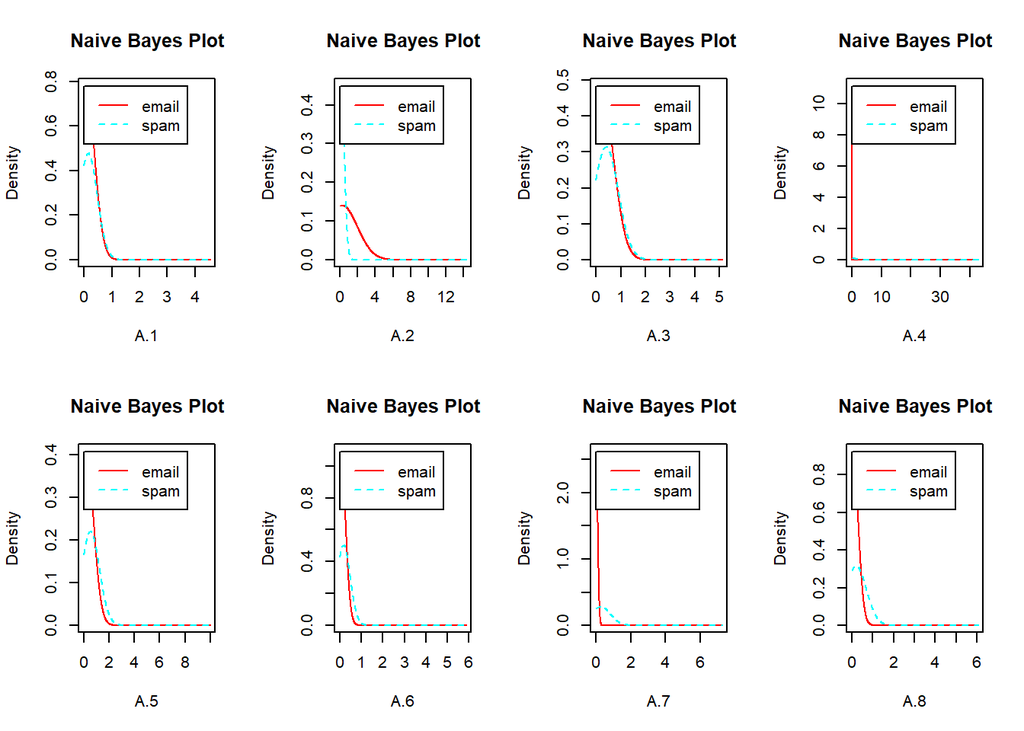

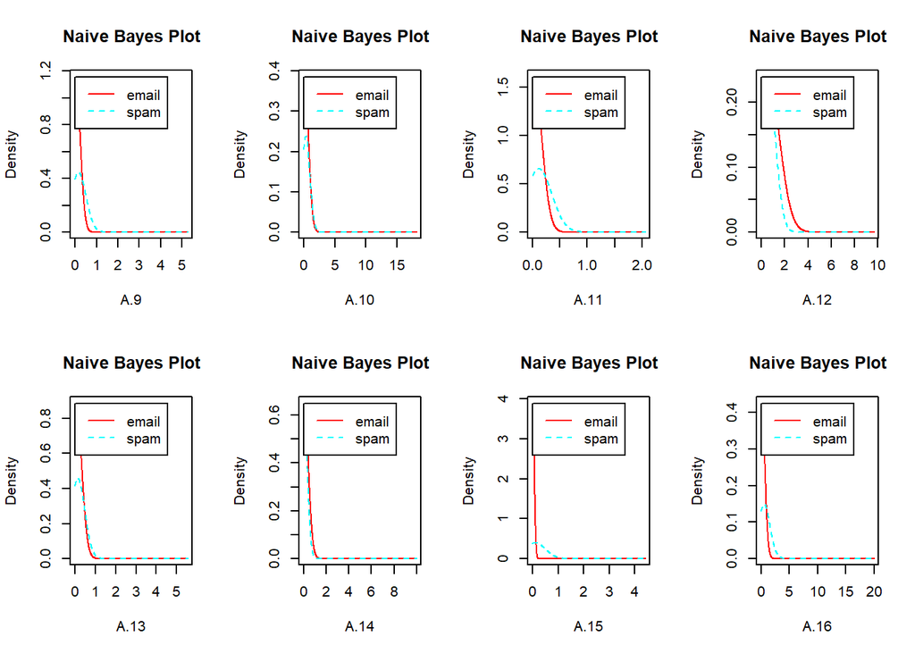

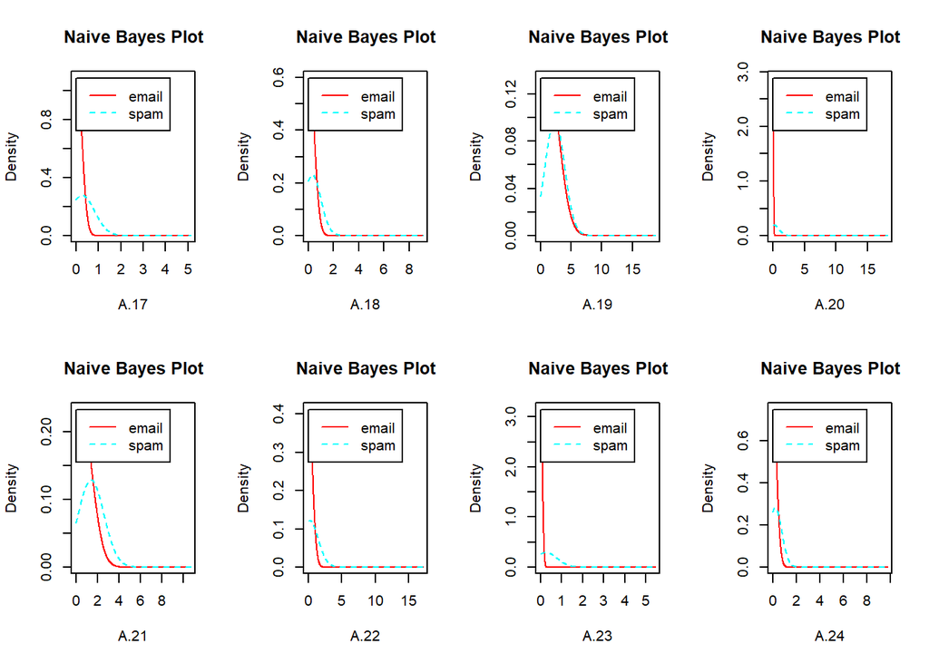

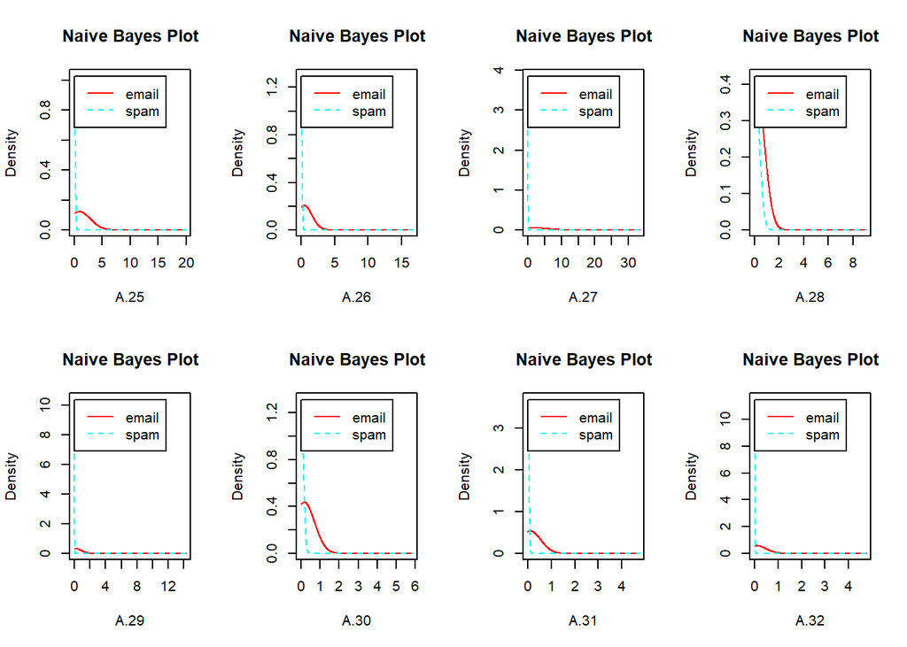

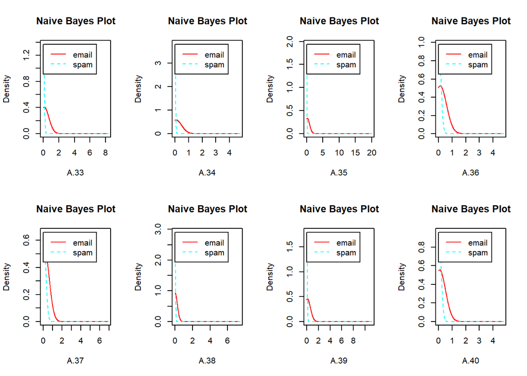

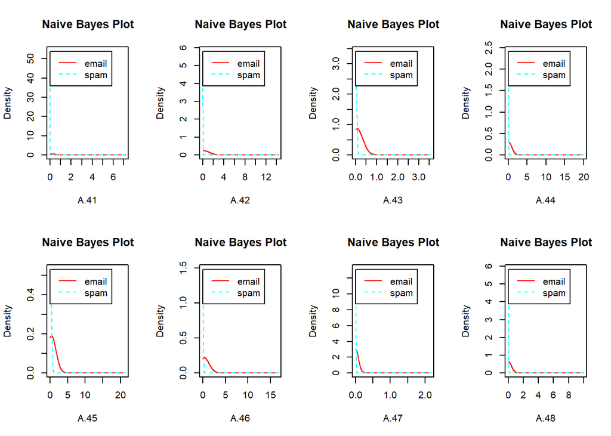

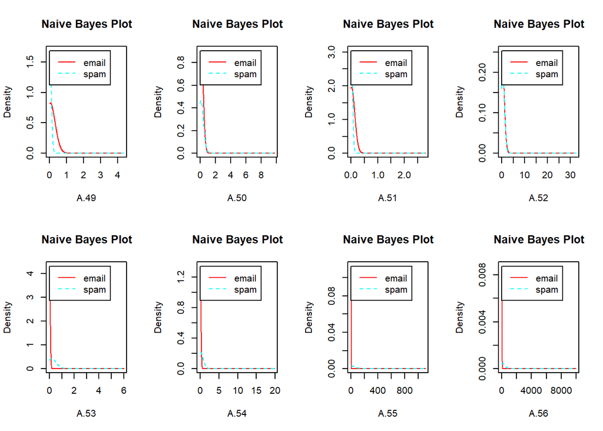

```r
train.ind = sample(1: nrow(spam), ceiling(nrow(spam) * 2 / 3), replace = FALSE)
nb.res = NaiveBayes(spam ~ ., data = spam[train.ind, ])

opar = par(mfrow = c(2, 4))
plot(nb.res)
```

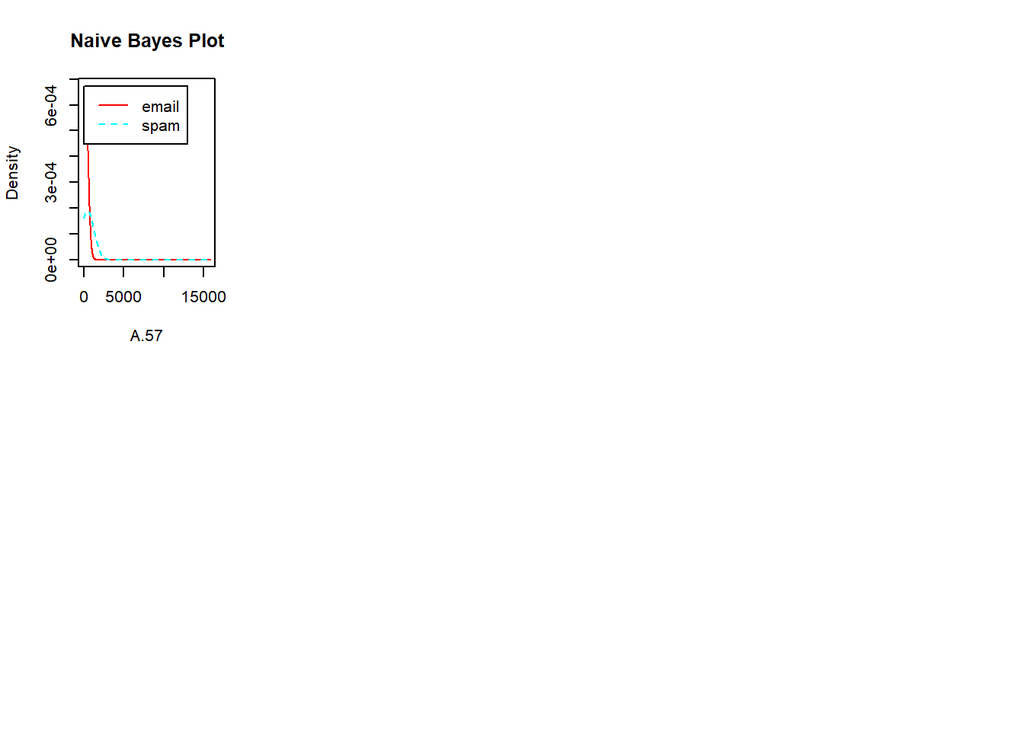

```r
par(opar)
```

```r
nb.pred = predict(nb.res, spam[-train.ind, ])
confusion.mat = table(nb.pred$class, spam[-train.ind, "spam"])
confusion.mat
```

```
##
##         email spam
##   email   518   34
##   spam    401  580
```

```r
sum(diag(confusion.mat)) / sum(confusion.mat)
```

```
## [1] 0.7162427
```

- 패키지 {klaR} : 분류 및 시각화를 위한 다양한 함수 제공
- 결측값 포함하는 자료 처리방법
  - 훈련단계 : 속성값-군집 조합에 대한 빈도 계산 시 결측값을 포함하는 케이스가 제외됨
  - 분류단계 : 결측인 속성이 계산과정에서 생략됨
- 예제 3.

```r
library(e1071)
data(HouseVotes84, package = "mlbench")
head(HouseVotes84)
```

```
##        Class   V1 V2 V3   V4   V5 V6 V7 V8 V9 V10  V11  V12 V13 V14 V15  V16
## 1 republican    n  y  n    y    y  y  n  n  n   y <NA>    y   y   y   n    y
## 2 republican    n  y  n    y    y  y  n  n  n   n    n    y   y   y   n <NA>
## 3   democrat <NA>  y  y <NA>    y  y  n  n  n   n    y    n   y   y   n    n
## 4   democrat    n  y  y    n <NA>  y  n  n  n   n    y    n   y   n   n    y
## 5   democrat    y  y  y    n    y  y  n  n  n   n    y <NA>   y   y   y    y
## 6   democrat    n  y  y    n    y  y  n  n  n   n    n    n   y   y   y    y
```

```r
summary(HouseVotes84)
```

```
##         Class        V1         V2         V3         V4         V5
##  democrat  :267   n   :236   n   :192   n   :171   n   :247   n   :208
##  republican:168   y   :187   y   :195   y   :253   y   :177   y   :212
##                   NA's: 12   NA's: 48   NA's: 11   NA's: 11   NA's: 15
##     V6         V7         V8         V9        V10        V11        V12
##  n   :152   n   :182   n   :178   n   :206   n   :212   n   :264   n   :233
##  y   :272   y   :239   y   :242   y   :207   y   :216   y   :150   y   :171
##  NA's: 11   NA's: 14   NA's: 15   NA's: 22   NA's:  7   NA's: 21   NA's: 31
##    V13        V14        V15        V16
##  n   :201   n   :170   n   :233   n   : 62
##  y   :209   y   :248   y   :174   y   :269
##  NA's: 25   NA's: 17   NA's: 28   NA's:104
```

```r
model = naiveBayes(Class ~ ., data = HouseVotes84)
pred = predict(model, HouseVotes84[, -1])
tab = table(pred, HouseVotes84$Class)
tab
```

```
##
## pred         democrat republican
##   democrat        238         13
##   republican       29        155
```

```r
table(HouseVotes84$Class)
```

```
##
##   democrat republican
##        267        168
```

```r
sum(tab[row(tab) == col(tab)]) / sum(tab)
```

```
## [1] 0.9034483
```